# Practical 1: Linear and logistic regression, random and fixed effect

Garyfallos Konstantinoudis

Spring Term 2024

## Part 1: Analysing type 2 diabetes progression using linear regression

Type 2 diabetes is a long-term metabolic disorder that is characterized by high blood sugar, insulin resistance, and relative lack of insulin. The number of people diagnosed with diabetes in the UK has more than doubled in the last twenty years. According to diabetes.org.uk/ figures show that there are now almost 3.7 million people living with a diagnosis of the condition in the UK, an increase of 1.9 million since 1998.

In this practical we consider an observational study that measures progression of type 2 diabetes (quantitative score) as outcome and several clinical parameters like age. sex, and bmi, but also common risk factors like map: blood pressure, tc: total cholesterol, ldl: low-density lipoprotein, hdl: high-density lipoprotein, tch: total cholesterol, ltg: triglycerides, and glu: glucose. The dataset includes n=442 cases. It is available in the lars package, which is easy to install using for example the install.packages(“lars”) command.

As a first step we load the data and assign x as a data.frame of the predictors and y as the quantitative score of type 2 diabetes progression.progression.

```r
library(lars)
data(diabetes)
x = as.data.frame.matrix(diabetes$x)
y = diabetes$y
```

From the literature we know that the following 6 predictors are important for type 2 diabetes progression: sex, age, bmi, glu, map and ltg. We consider these 6 predictors as model 1.

Question 1.1 Look at the correlation structure between those 6 predictors and discuss the implications. Use the function corrplot() in the corrplot package to visualise the correlation structure.

*Reply: The command cor() computes the correlation matrix between the indicated variables.*

```r
library(corrplot)
x_cor=x[,c("sex","age","bmi","glu","map","ltg")]
cor(x_cor)
```

```
##           sex       age       bmi       glu       map       ltg
## sex 1.0000000 0.1737371 0.0881614 0.2081332 0.2410132 0.1499176
## age 0.1737371 1.0000000 0.1850847 0.3017310 0.3354267 0.2707768
## bmi 0.0881614 0.1850847 1.0000000 0.3886800 0.3954153 0.4461586
## glu 0.2081332 0.3017310 0.3886800 1.0000000 0.3904294 0.4646705
## map 0.2410132 0.3354267 0.3954153 0.3904294 1.0000000 0.3934781
## ltg 0.1499176 0.2707768 0.4461586 0.4646705 0.3934781 1.0000000
```

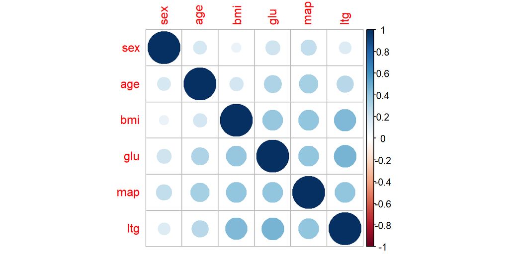

```r
corrplot(cor(x_cor))
```

*The correlation between the predictors is low to moderate. The strongest correlation is observed between ltg, map, glu, and bmi.*

Question 1.2 Does the outcome disease progression follow a Normal-distribution? Look at general summary statistics of y, plot a histogram and a q-q plot against the Normal-distribution.

*Reply: The outcome is certainly not perfectly Normal-distributed, but for now this assumption is fine.*

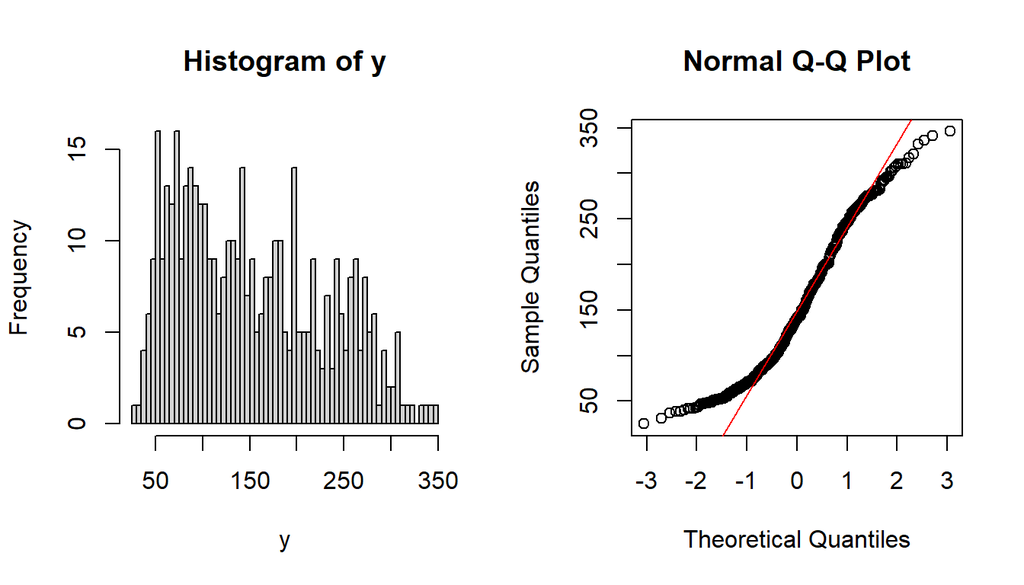

```r
par(mfrow=c(1,2))
hist(y,breaks=50)
qqnorm(y)
qqline(y,col="red")
```

```r
par(mfrow=c(1,1))
```

Question 1.3 Fit a linear model including the predictors of model 1 (sex, age, bmi, glu, map and ltg) using the lm() function and discuss the summary of the model.

```r
lm1 = lm(y~sex+age+bmi+glu+map+ltg, data=x)
summary(lm1)
```

```
##
## Call:
## lm(formula = y ~ sex + age + bmi + glu + map + ltg, data = x)
##
## Residuals:
##      Min       1Q   Median       3Q      Max
## -150.043  -39.021   -2.356   38.871  142.753
##
## Coefficients:
##             Estimate Std. Error t value Pr(>|t|)
## (Intercept)  152.133      2.641  57.610  < 2e-16 ***
## sex         -139.901     57.931  -2.415   0.0161 *
## age          -45.201     60.581  -0.746   0.4560
## bmi          586.705     65.453   8.964  < 2e-16 ***
## glu           68.628     66.989   1.024   0.3062
## map          292.048     66.417   4.397 1.38e-05 ***
## ltg          540.784     67.806   7.975 1.35e-14 ***
## ---
## Signif. codes:  0 '***' 0.001 '**' 0.01 '*' 0.05 '.' 0.1 ' ' 1
##
## Residual standard error: 55.52 on 435 degrees of freedom
## Multiple R-squared:  0.4884, Adjusted R-squared:  0.4814
## F-statistic: 69.22 on 6 and 435 DF,  p-value: < 2.2e-16
```

Question 1.4 Perform model diagnostics and outlier detection of model 1. Do you think this is a good model fit? Justify your answers.

*Reply: All of the diagnostic plots look fine.*

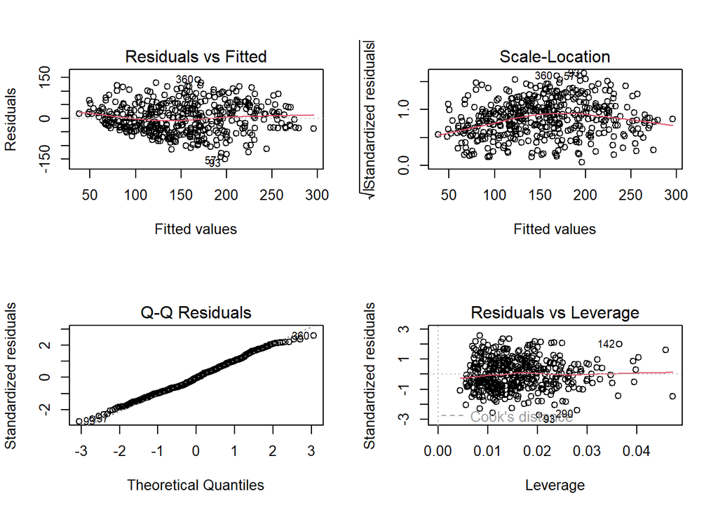

```r
par(mfrow=c(2,2))
plot(lm1,which=1)
plot(lm1,which=3)
plot(lm1,which=2)
plot(lm1,which=5)
```

```r
par(mfrow=c(1,1))
```

Question 1.5 For model 1, compute the OLS regression coefficient estimate using matrix multiplication $\hat{\beta}_{OLS}=(x^t x)^{-1} x^t y$. Use the solve() function to invert a matrix. R distinguishes between scalar multiplication ($\ast$) and matrix multiplication (%$\ast$%). Make sure to use the matrix multiplication (%$\ast$%) for this task and ensure that your matrices have the correct dimensions. Add an intercept by including a row of ones like for example this.

```r
x1 =  cbind(rep(1,nrow(diabetes$x)), x$sex, x$age, x$bmi, x$glu, x$map, x$ltg)
```

*Reply:*

```r
beta_ols = solve(t(x1) %*% x1) %*% t(x1) %*% y
```

Question 1.6 Compute the regression coefficient estimate using the sample covariance based estimate, defined as $\hat{\beta}_{COV}=cov(x)^{-1} cov(xy)$. Use the solve() function to invert the covariance matrix cov(x) of dimension 6 x 6 and compute this estimate without the intercept using

```r
x11 =  cbind(x$sex, x$age, x$bmi, x$glu, x$map, x$ltg)
```

As an additional hint, please use the solve() function to invert the covariance matrix cov(x) of dimension 6 x 6.

*Reply:*

```r
beta_cov = solve(cov(x11)) %*% cov(x11,y)
```

Question 1.7 Compare the 3 regression coefficient estimates from questions 1.3, 1.5 and 1.6.

*Reply: All three estimators give the same answer for the regression coefficients.*

```r
compare_beta = matrix(NaN, ncol = 3, nrow = 7)
colnames(compare_beta)=c("lm","ols","cov")
compare_beta[,1] = lm1$coefficients
compare_beta[,2] = beta_ols
compare_beta[2:7,3] = beta_cov
compare_beta
```

```
##              lm        ols        cov
## [1,]  152.13348  152.13348        NaN
## [2,] -139.90054 -139.90054 -139.90054
## [3,]  -45.20079  -45.20079  -45.20079
## [4,]  586.70493  586.70493  586.70493
## [5,]   68.62836   68.62836   68.62836
## [6,]  292.04767  292.04767  292.04767
## [7,]  540.78417  540.78417  540.78417
```

Question 1.8 Fit model 2 that only includes glucose and compare how it differs from the multivariable model 1.

*Reply: The effect of glucose substantially attenuates after conditioning on other covariates. In an univariable model the beta is 619, while in the multivariable model the effect is 69 and not significant. This might suggest that the disease progression does not depend on glu but on other correlated risk factors. Also the adjusted R-squared (0.1444) is much smaller than in the multivariable model.*

```r
lm2=lm(y~glu, data = x)
summary(lm2)
```

```
##
## Call:
## lm(formula = y ~ glu, data = x)
##
## Residuals:
##      Min       1Q   Median       3Q      Max
## -153.069  -57.716   -5.466   54.656  186.839
##
## Coefficients:
##             Estimate Std. Error t value Pr(>|t|)
## (Intercept)  152.133      3.392  44.851   <2e-16 ***
## glu          619.223     71.312   8.683   <2e-16 ***
## ---
## Signif. codes:  0 '***' 0.001 '**' 0.01 '*' 0.05 '.' 0.1 ' ' 1
##
## Residual standard error: 71.31 on 440 degrees of freedom
## Multiple R-squared:  0.1463, Adjusted R-squared:  0.1444
## F-statistic:  75.4 on 1 and 440 DF,  p-value: < 2.2e-16
```

## Part 2: Predict type 2 diabetes progression using linear regression

Assume we only observed the first 300 cases and use these cases as training data.

```r
x_train = data.frame(x[1:300,])
y_train = y[1:300]
```

Now we can consider the remaining 142 cases as new data points for whom we want to predict disease progression.

```r
x_new = data.frame(x[301:442,])
y_new = y[301:442]
```

Question 2.1 Use the linear model 1 to predict the disease progression for the 142 cases with predictor information stored in x_new.

*Reply:*

```r
lm1_train = lm(y_train~sex+age+bmi+glu+map+ltg, data=x_train)
y_predict1 = predict.lm(lm1_train,x_new)
```

Question 2.2 Evaluate the error of your prediction based on linear model 1 by computing the squared difference between the predicted progression and the actual observed progression saved in y_new. Plot a histogram of the squared difference and compute the mean and median.

*Reply:*

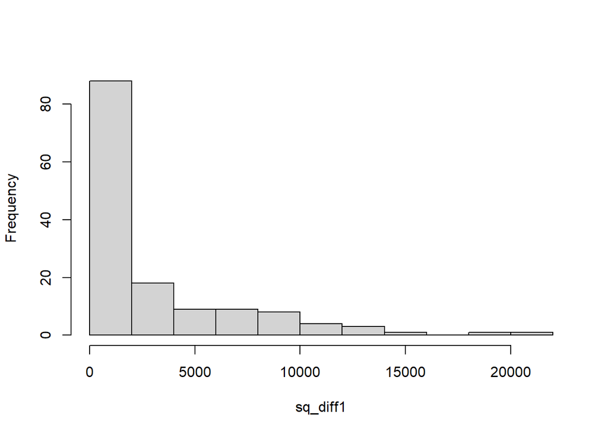

```r
sq_diff1 = (y_predict1 - y_new)^2
hist(sq_diff1, main="")
```

```r
summary(sq_diff1)
```

```
##      Min.   1st Qu.    Median      Mean   3rd Qu.      Max.
##     0.001   280.290  1510.249  2979.775  4032.200 20455.815
```

Question 2.3 Repeat the steps 2.1 and 2.2 using the univariable linear model 2 including only glucose. Contrast the prediction error of linear model 2 with the prediction error of linear model 1.

*Reply: The prediction using model 2 (glu) has a much larger mean squared error (MSE) than model 1 (sex, age, bmi, glu, map and ltg).*

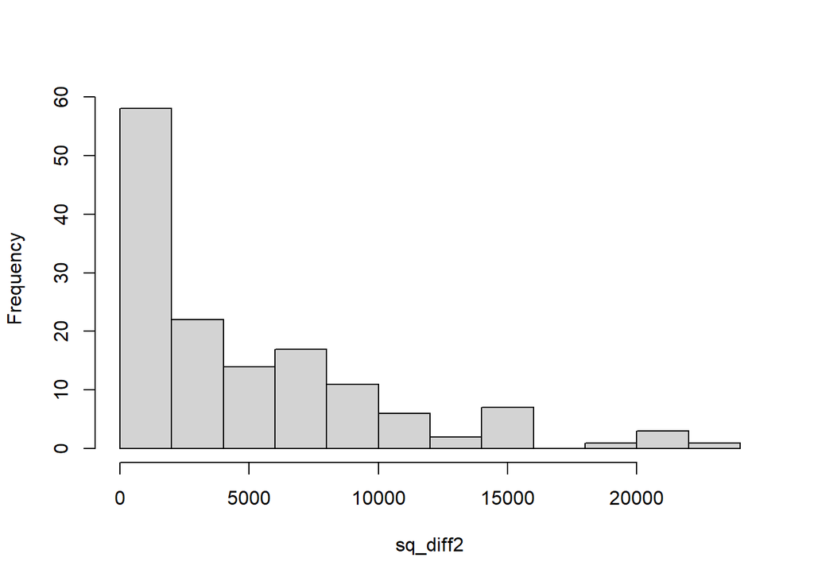

```r
lm2_train = lm(y_train~glu, data=x_train)
y_predict2 = predict.lm(lm2_train,x_new)
sq_diff2 = (y_predict2 - y_new)^2
hist(sq_diff2, main="")
```

```r
summary(sq_diff2)
```

```
##      Min.   1st Qu.    Median      Mean   3rd Qu.      Max.
##     2.055   923.010  3074.797  4975.382  7295.496 22350.041
```

Question 2.4 Is it good practise to evaluate the prediction performance on a single training data? How appropriate is the split to take the first 300 cases?

*Reply: No, ideally one would repeat the process (split the data, learn the prediction rule and evaluate) many times to eliminate the randomness of the data split. When just doing this process once we only might capture a prediction rule that is specific for the first 300 cases, but does not generalise to other data-sets. The main aim of building a prediction rule is that it generalises to new data.*

## Part 3: Distinguishing between severe and mild cases of type 2 diabetes using logistic regression

Doctors are particularly concerned with type 2 diabetes cases that have a bad disease progression, in particular cases that have a disease progression score larger than 200. Binarise your outcome like this:

```r
y_binary = as.numeric(y>200)
```

Question 3.1 Fit a generalised linear model using the glm() function that can distinguish between bad disease progression and normal progression. Use the 6 predictors as considered in model 1. Look at the summary of the glm output and interpret the findings.

```r
glm1 = glm(y_binary~sex+age+bmi+glu+map+ltg, data = x, family=binomial)
summary(glm1)
```

```
##
## Call:
## glm(formula = y_binary ~ sex + age + bmi + glu + map + ltg, family = binomial,
##     data = x)
##
## Coefficients:
##             Estimate Std. Error z value Pr(>|z|)
## (Intercept)  -1.6504     0.1753  -9.416  < 2e-16 ***
## sex          -2.3334     3.0187  -0.773    0.440
## age          -1.7950     3.3780  -0.531    0.595
## bmi          21.0236     3.6247   5.800 6.63e-09 ***
## glu           1.0369     3.5349   0.293    0.769
## map          13.2277     3.3866   3.906 9.39e-05 ***
## ltg          22.0036     3.7190   5.917 3.29e-09 ***
## ---
## Signif. codes:  0 '***' 0.001 '**' 0.01 '*' 0.05 '.' 0.1 ' ' 1
##
## (Dispersion parameter for binomial family taken to be 1)
##
##     Null deviance: 518.87  on 441  degrees of freedom
## Residual deviance: 323.04  on 435  degrees of freedom
## AIC: 337.04
##
## Number of Fisher Scoring iterations: 6
```

Question 3.2 Consider now model 2 including only glucose. Fit a glm and see if glucose can distinguish between bad disease progression and normal progression.

*Reply: When not considering the other covariates the effect of glu becomes highly significant also for the binary trait. But again the model fit (look here at AIC (Lecture 2a)) is not as good as for model 1. The AIC of model 1 is much smaller than the AIC of model 2, thus model 1 provides the better overall fit.*

```r
glm2 = glm(y_binary~glu, data = x, family=binomial)
summary(glm2)
```

```
##
## Call:
## glm(formula = y_binary ~ glu, family = binomial, data = x)
##
## Coefficients:
##             Estimate Std. Error z value Pr(>|z|)
## (Intercept)   -1.098      0.118  -9.303  < 2e-16 ***
## glu           16.587      2.604   6.370 1.89e-10 ***
## ---
## Signif. codes:  0 '***' 0.001 '**' 0.01 '*' 0.05 '.' 0.1 ' ' 1
##
## (Dispersion parameter for binomial family taken to be 1)
##
##     Null deviance: 518.87  on 441  degrees of freedom
## Residual deviance: 471.24  on 440  degrees of freedom
## AIC: 475.24
##
## Number of Fisher Scoring iterations: 4
```

Question 3.3 Look again at the training data (x_train and ybin_train) based on the first 300 cases, where

```r
ybin_train = y_binary[1:300]
```

Build a prediction rule based on model 1 using the training data (x_train and ybin_train) using the glm function. In a second step predict which of the new samples (using x_new as predictor matrix) are at high risk for having a bad diagnosis. How many of the 142 new observations have a probability larger than 0.5 to have bad progression?

PS Use the inverse logit function $(logit^{-1} (eta) = exp(eta)/(exp(eta) + 1))$ to transform the linear predictor $(eta = x \beta)$ back to a probability which ranges between 0 and 1.

*Reply: First we learn the prediction rule and we predict the linear predictor eta for the new observations. Note that eta is on the linear and continuous scale.*

```r
glm_predict = glm(ybin_train~sex+age+bmi+glu+map+ltg, data = x_train, family=binomial)
eta = predict.glm(glm_predict,x_new)
summary(eta)
```

```
##    Min. 1st Qu.  Median    Mean 3rd Qu.    Max.
##  -6.663  -3.382  -1.574  -1.535   0.200   4.258
```

*In order to transform the linear predictor to probabilities we use the inverse logit link. There are 39 cases that are predicted to have a bad disease progression.*

```r
p_predict = (exp(eta)/(exp(eta)+1))
summary(p_predict)
```

```
##     Min.  1st Qu.   Median     Mean  3rd Qu.     Max.
## 0.001275 0.032886 0.171826 0.308790 0.549780 0.986044
```

```r
sum(p_predict>0.5)
```

```
## [1] 39
```

## Part 4 (Optional): Which risk factors are important for type 2 diabetes progression?

Look again at the complete dataset including all n=442 cases and all 10 predictors. How would you perform variable selection to decide which variables are important for disease progression in type 2 diabetes?

*Reply: First we can fit a linear regression including all predictors.*

```r
lm_all=lm(y~as.matrix(x))
summary(lm_all)
```

```
##
## Call:
## lm(formula = y ~ as.matrix(x))
##
## Residuals:
##      Min       1Q   Median       3Q      Max
## -155.829  -38.534   -0.227   37.806  151.355
##
## Coefficients:
##                 Estimate Std. Error t value Pr(>|t|)
## (Intercept)      152.133      2.576  59.061  < 2e-16 ***
## as.matrix(x)age  -10.012     59.749  -0.168 0.867000
## as.matrix(x)sex -239.819     61.222  -3.917 0.000104 ***
## as.matrix(x)bmi  519.840     66.534   7.813 4.30e-14 ***
## as.matrix(x)map  324.390     65.422   4.958 1.02e-06 ***
## as.matrix(x)tc  -792.184    416.684  -1.901 0.057947 .
## as.matrix(x)ldl  476.746    339.035   1.406 0.160389
## as.matrix(x)hdl  101.045    212.533   0.475 0.634721
## as.matrix(x)tch  177.064    161.476   1.097 0.273456
## as.matrix(x)ltg  751.279    171.902   4.370 1.56e-05 ***
## as.matrix(x)glu   67.625     65.984   1.025 0.305998
## ---
## Signif. codes:  0 '***' 0.001 '**' 0.01 '*' 0.05 '.' 0.1 ' ' 1
##
## Residual standard error: 54.15 on 431 degrees of freedom
## Multiple R-squared:  0.5177, Adjusted R-squared:  0.5066
## F-statistic: 46.27 on 10 and 431 DF,  p-value: < 2.2e-16
```

*The full model includes many covariates that do not have a significant effect, eg. age or hdl. Still for the interpretation we would prefer to have our model adjusted for age. Some clincal covariates might be better left in a model so that they do not act as a confounder. With respect to variable selection, backward or forward selection are often used, but they are not recommended as these approaches depend on the order how variables are included. In case you want to test a very specific hypothesis, for example if glu should be included or not it is possible to use an anova test for linear models.*

```r
lm_noglu=lm(y~as.matrix(x[,-10]))
anova(lm_noglu,lm_all)
```

|  | Res.Df | RSS | Df | Sum of Sq | F | Pr(>F) |
| --- | --- | --- | --- | --- | --- | --- |
| 1 | 432 | 1267064 | NA | NA | NA | NA |
| 2 | 431 | 1263983 | 1 | 3080.374 | 1.050363 | 0.3059983 |

*The above test says that there is no improvement in the model fit when including glu. This type of comparison of nested models is only valid to test very specific hypothesis, and not for variable selection in general. In lectures 2a and 2b we will learn more about variable selection and in lecture 3c we cover regularised regression approaches like lasso and elastic net that can perform variable selection and in lectures 4b we cover machine learning approaches to define variable importance.*

## Part 5: Linear mixed model: Exam scores from London

This section considers exam scores of 3,935 students from 65 schools in Inner London. In particular, we want to find out how the final exam score can be predicted by reading abilities as measured in the London reading (LR) test. Please adjust the path to the dataset according to your computational setup.

```r
load("../../data/exam.London")
```

Additional covariates of the data are:

- school: School ID - a factor
- schgend: School gender - a factor. Levels are ‘mixed’, ‘boys’, and ‘girls’
- schavg: School average of intake score
- vr: Student level Verbal Reasoning (VR) score band at intake - ‘bottom 25%’, ‘mid 50%’, and ‘top 25%’
- intake: Band of student’s intake score - ‘bottom 25%’, ‘mid 50%’ and ‘top 25%’
- sex: Sex of the student - levels are ‘F’ and ‘M’
- type: School type - levels are ‘Mxd’ and ‘Sngl’
- student: Student id (within school) - a factor

Question 5.1

Fit a linear model to test if there is a linear relationship between reading ability and the final exam score and plot a scatterplot of exam score against reading ability.

```r
exam.lm = lm(normexam~standLRT, data=exam)
summary(exam.lm)
```

```
##
## Call:
## lm(formula = normexam ~ standLRT, data = exam)
##
## Residuals:
##     Min      1Q  Median      3Q     Max
## -2.6518 -0.5182  0.0122  0.5404  2.9766
##
## Coefficients:
##              Estimate Std. Error t value Pr(>|t|)
## (Intercept) -0.003163   0.012873  -0.246    0.806
## standLRT     0.596474   0.012972  45.981   <2e-16 ***
## ---
## Signif. codes:  0 '***' 0.001 '**' 0.01 '*' 0.05 '.' 0.1 ' ' 1
##
## Residual standard error: 0.8075 on 3933 degrees of freedom
## Multiple R-squared:  0.3496, Adjusted R-squared:  0.3495
## F-statistic:  2114 on 1 and 3933 DF,  p-value: < 2.2e-16
```

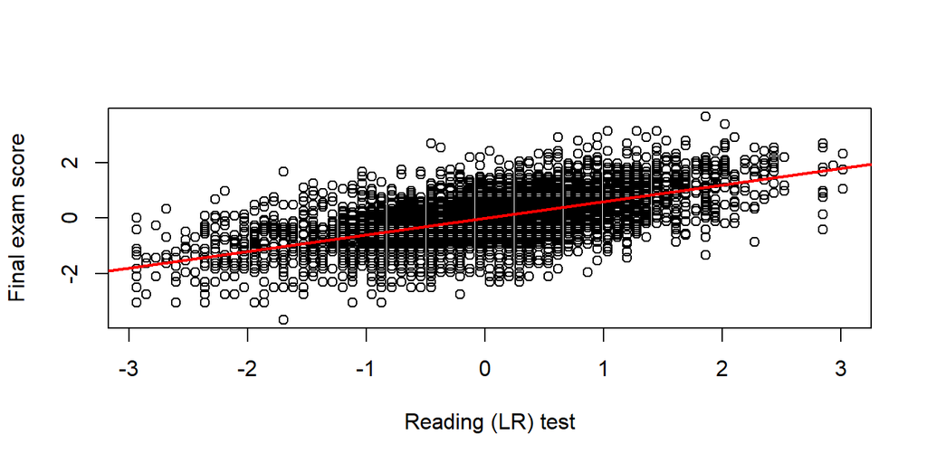

```r
plot(exam$standLRT,exam$normexam, xlab="Reading (LR) test", ylab="Final exam score")
abline(exam.lm, lwd=2, col="red")
```

*Reply: There is a linear relationship between reading ability (standardised London reading test) and the final exam score. An increase of 1 in the reading score, increases the final exam score by 0.596474.*

Question 5.2

Are there any potential issues with the standard linear model?

*Reply: Yes, this linear model treats all observations as independent and disregards the potential group structure as induced by the school in which the students are studying.*

Question 5.3

Fit a fixed effect model accounting for the effect of schools using the lm() function where you add school (as.factor()) as covariate. What is the interpretation of the model and how many additional parameters do we need to estimate?

```r
exam.fe = lm(normexam~standLRT+as.factor(school), data=exam)
coef(exam.fe)
```

```
##         (Intercept)            standLRT  as.factor(school)2  as.factor(school)3
##         0.405549804         0.560181196         0.156197429         0.168658362
##  as.factor(school)4  as.factor(school)5  as.factor(school)6  as.factor(school)7
##        -0.383878052        -0.134037654         0.181827272        -0.026970604
##  as.factor(school)8  as.factor(school)9 as.factor(school)10 as.factor(school)11
##        -0.413833357        -0.523084933        -0.780966981        -0.179456700
## as.factor(school)12 as.factor(school)13 as.factor(school)14 as.factor(school)15
##        -0.483312036        -0.571058377        -0.581067253        -0.606702657
## as.factor(school)16 as.factor(school)17 as.factor(school)18 as.factor(school)19
##        -0.825202132        -0.595818835        -0.490771143        -0.431115211
## as.factor(school)20 as.factor(school)21 as.factor(school)22 as.factor(school)23
##        -0.205049233        -0.126419704        -0.880185131        -1.000512830
## as.factor(school)24 as.factor(school)25 as.factor(school)26 as.factor(school)27
##        -0.179747660        -0.666833203        -0.429359943        -0.378424526
## as.factor(school)28 as.factor(school)29 as.factor(school)30 as.factor(school)31
##        -1.106500587        -0.163003687        -0.212081930        -0.414259745
## as.factor(school)32 as.factor(school)33 as.factor(school)34 as.factor(school)35
##        -0.411342710        -0.356107503        -0.537174088        -0.214086960
## as.factor(school)36 as.factor(school)37 as.factor(school)38 as.factor(school)39
##        -0.640611796        -0.647423110        -0.574310199        -0.241066377
## as.factor(school)40 as.factor(school)41 as.factor(school)42 as.factor(school)43
##        -0.645538637        -0.170886794        -0.306591722        -0.497881063
## as.factor(school)44 as.factor(school)45 as.factor(school)46 as.factor(school)47
##        -0.688387983        -0.520295271        -0.788708334        -0.455262007
## as.factor(school)48 as.factor(school)49 as.factor(school)50 as.factor(school)51
##        -0.587882734        -0.370351439        -0.744855302        -0.461041141
## as.factor(school)52 as.factor(school)53 as.factor(school)54 as.factor(school)55
##         0.008072604         0.398475436        -1.368601638         0.184024334
## as.factor(school)56 as.factor(school)57 as.factor(school)58 as.factor(school)59
##        -0.427019374        -0.377376447        -0.241451121        -1.128811022
## as.factor(school)60 as.factor(school)61 as.factor(school)62 as.factor(school)63
##        -0.143876751        -0.438222462        -0.493550060         0.242290425
## as.factor(school)64 as.factor(school)65
##        -0.304716265        -0.593671312
```

*Reply: Also the fixed effects model finds a linear relationship where the regression coefficient equals 0.560181196. By introducing the factor school as covariate we need to estimate additional to the intercept and the beta regression coefficient another 64 regression parameter, one for each school minus the reference category. In total these are 66 parameters to estimate in a fixed effects model.*

Question 5.4

Now use the function in the lme function in the

```r
library(nlme)
```

package to estimate a random effects model with a random intercept depending on the school. What is the interpretation of the fixed effect? How many parameters do we need to estimate compared to the fixed effects model?

```r
RandomIntercept = lme(normexam~standLRT,  random = ~1|school, data=exam)
summary(RandomIntercept)
```

```
## Linear mixed-effects model fit by REML
##   Data: exam
##        AIC      BIC    logLik
##   9107.902 9133.011 -4549.951
##
## Random effects:
##  Formula: ~1 | school
##         (Intercept)  Residual
## StdDev:   0.3071927 0.7535887
##
## Fixed effects:  normexam ~ standLRT
##                 Value  Std.Error   DF  t-value p-value
## (Intercept) 0.0003680 0.04052258 3869  0.00908  0.9928
## standLRT    0.5641318 0.01269508 3869 44.43704  0.0000
##  Correlation:
##          (Intr)
## standLRT 0.007
##
## Standardized Within-Group Residuals:
##         Min          Q1         Med          Q3         Max
## -3.69766166 -0.62537566  0.02378645  0.67363330  3.25607135
##
## Number of Observations: 3935
## Number of Groups: 65
```

*Reply: There is almost no change in the interpretation of the random effects model, also here the reading ability has a linear relationship with the exam score (beta=0.5641318). We need to estimate two additional parameters, StdDev(Intercept), StdDev(Residual), so in total there are 4 parameters, 62 parameters less than in the fixed effects model.*

Question 5.5

What is the intra-class correlation coefficient for this model (lecture 1c, slide 38-40) and how do you interpret it?

```r
std.u = 0.3071927
std.e = 0.7535887
rho = std.u^2 / (std.u^2+std.e^2)
rho
```

```
## [1] 0.1424922
```

*Reply: The intra-class correlation coefficient is 0.1424922, which is not strong, but still it should be accounted for.*

Question 5.6

Add a random slope depending on school to your model and see if the effect of the fixed effects changes.

```r
RandomSlope = lme(fixed=normexam~standLRT, random = ~ 1 + standLRT | school, data = exam)
summary(RandomSlope)
```

```
## Linear mixed-effects model fit by REML
##   Data: exam
##        AIC      BIC    logLik
##   9073.433 9111.096 -4530.716
##
## Random effects:
##  Formula: ~1 + standLRT | school
##  Structure: General positive-definite, Log-Cholesky parametrization
##             StdDev    Corr
## (Intercept) 0.3036539 (Intr)
## standLRT    0.1195874 0.515
## Residual    0.7457559
##
## Fixed effects:  normexam ~ standLRT
##                  Value  Std.Error   DF   t-value p-value
## (Intercept) -0.0128592 0.04019296 3869 -0.319936   0.749
## standLRT     0.5572347 0.01999295 3869 27.871557   0.000
##  Correlation:
##          (Intr)
## standLRT 0.374
##
## Standardized Within-Group Residuals:
##         Min          Q1         Med          Q3         Max
## -3.81039335 -0.63401728  0.03275735  0.67303397  3.44692474
##
## Number of Observations: 3935
## Number of Groups: 65
```

*Reply: No, the strength of the fixed effect of reading ability stays roughly constant with a beta equal to 0.5572344.*

Question 5.7

Which of the covariates are individual-level and which are group-level variables? Re-fit your random intercept model adding the group-level variables to the random effects model.

```r
RandomInterceptCov = lme( normexam~standLRT + schavg + schgend, random = ~ 1 | school, data = exam)
summary(RandomInterceptCov)
```

```
## Linear mixed-effects model fit by REML
##   Data: exam
##        AIC     BIC    logLik
##   9104.396 9148.33 -4545.198
##
## Random effects:
##  Formula: ~1 | school
##         (Intercept)  Residual
## StdDev:   0.2649784 0.7537166
##
## Fixed effects:  normexam ~ standLRT + schavg + schgend
##                   Value  Std.Error   DF  t-value p-value
## (Intercept)  -0.0814454 0.04847661 3869 -1.68010  0.0930
## standLRT      0.5601841 0.01276782 3869 43.87470  0.0000
## schavg        0.3519672 0.10711677   61  3.28583  0.0017
## schgendboys   0.1158202 0.10330517   61  1.12115  0.2666
## schgendgirls  0.2404062 0.08041229   61  2.98967  0.0040
##  Correlation:
##              (Intr) stnLRT schavg schgndb
## standLRT      0.000
## schavg        0.053 -0.119
## schgendboys  -0.465 -0.001  0.053
## schgendgirls -0.603 -0.001 -0.031  0.280
##
## Standardized Within-Group Residuals:
##         Min          Q1         Med          Q3         Max
## -3.69621679 -0.62854698  0.02257168  0.67400518  3.22267911
##
## Number of Observations: 3935
## Number of Groups: 65
```

*Reply: Group-level covariates are school gender, school average of intake score and school type. We add here the covariates school gender and school average of intake score. We find that the school average of intake score and the effect of being in a girls only school have a significant positive effect. The fixed effect of reading ability (beta=0.5601841) is comparable to other models.*

Question 5.8

Compare the random intercept (Q5.4) and the random intercept and slope model (Q5.6) using the likelihood ratio test and discuss which one has the better model fit.

```r
library(lmtest)
lrtest(RandomIntercept, RandomSlope)
```

|  | #Df | LogLik | Df | Chisq | Pr(>Chisq) |
| --- | --- | --- | --- | --- | --- |
| 1 | 4 | -4549.951 | NA | NA | NA |
| 2 | 6 | -4530.716 | 2 | 38.46905 | 4.431505e-09 |

```r
# notice that the anova() function gives more information
anova(RandomIntercept, RandomSlope)
```

|  | call | Model | df | AIC | BIC | logLik | Test | L.Ratio | p-value |
| --- | --- | --- | --- | --- | --- | --- | --- | --- | --- |
| RandomIntercept | lme.formula(fixed = normexam ~ standLRT, data = exam, random = ~1 \| school) | 1 | 4 | 9107.902 | 9133.011 | -4549.951 |  | NA | NA |
| RandomSlope | lme.formula(fixed = normexam ~ standLRT, data = exam, random = ~1 + standLRT \| school) | 2 | 6 | 9073.433 | 9111.096 | -4530.716 | 1 vs 2 | 38.46905 | 4.431505e-09 |

*Reply: The random slope model has a better model fit than the random intercept model in all criteria, likelihood ratio (these are nested models, so it is ok to interpret the the likelihood ratio test here), AIC and BIC.*

Question 5.9

Compare the random intercept model (Q5.4) and the one with the additional covariates (Q5.7) using the AIC and BIC (note that those two models are not nested) and discuss which one has the better model fit.

```r
anova(RandomIntercept, RandomInterceptCov)
```

|  | call | Model | df | AIC | BIC | logLik | Test | L.Ratio | p-value |
| --- | --- | --- | --- | --- | --- | --- | --- | --- | --- |
| RandomIntercept | lme.formula(fixed = normexam ~ standLRT, data = exam, random = ~1 \| school) | 1 | 4 | 9107.902 | 9133.011 | -4549.951 |  | NA | NA |
| RandomInterceptCov | lme.formula(fixed = normexam ~ standLRT + schavg + schgend, data = exam, random = ~1 \| school) | 2 | 7 | 9104.396 | 9148.330 | -4545.198 | 1 vs 2 | 9.506363 | 0.02326377 |

*Reply: Since the two models are not nested we need to compare them using the AIC and BIC. We find that there is no conclusive improvement when adding the covariates. Using the AIC the covariate model would be better, using the BIC the intercept only model is better.*

## Part 6: Linear mixed model: Survival on the Titanic

The sinking of the titanic was one of the greatest disaster in navel history. After colliding with an iceberg, the titanic sank and 1,502 out of 2,224 passengers and crew were killed. The following data set has collected information on n=1,309 of the passengers and their survival.

```r
titanic = read.csv("../../data/titanic.csv")
dim(titanic)
```

```
## [1] 1309   14
```

```r
table(titanic$survived)
```

```
##
##   0   1
## 809 500
```

The dataset includes:

- survival: Survival (0 = No; 1 = Yes)
- class: Passenger Class (1 = 1st; 2 = 2nd; 3 = 3rd)
- name: Name
- sex: Sex (1=female, 2=male)
- age: Age
- sibsp: Number of Siblings/Spouses Aboard
- parch: Number of Parents/Children Aboard
- ticket: Ticket Number
- fare: Passenger Fare
- cabin: Cabin
- embarked: Port of Embarkation (C = Cherbourg; Q = Queenstown; S = Southampton)
- boat: Lifeboat (if survived)
- body: Body number (if did not survive and body was recovered)

For more information on the data and a data challenge called ‘Machine Learning from Disaster’ see

https://www.kaggle.com/c/titanic

In the following we want to test if the phrase ‘women and children first’ was adapted for the evacuation of the titanic.

Question 6.1

Since survival is a binary outcome here, use a glm to test if age and sex had an effect on survival.

```r
glm.out = glm(as.factor(survived)~as.factor(sex)+age, family = "binomial", data = titanic)
summary(glm.out)
```

```
##
## Call:
## glm(formula = as.factor(survived) ~ as.factor(sex) + age, family = "binomial",
##     data = titanic)
##
## Coefficients:
##                     Estimate Std. Error z value Pr(>|z|)
## (Intercept)         1.235414   0.192032   6.433 1.25e-10 ***
## as.factor(sex)male -2.460689   0.152315 -16.155  < 2e-16 ***
## age                -0.004254   0.005207  -0.817    0.414
## ---
## Signif. codes:  0 '***' 0.001 '**' 0.01 '*' 0.05 '.' 0.1 ' ' 1
##
## (Dispersion parameter for binomial family taken to be 1)
##
##     Null deviance: 1414.6  on 1045  degrees of freedom
## Residual deviance: 1101.3  on 1043  degrees of freedom
##   (263 observations deleted due to missingness)
## AIC: 1107.3
##
## Number of Fisher Scoring iterations: 4
```

*Reply: We indeed see a worse chance of survival for men, but no effect of age.*

Question 6.2

Next step is to account for the passenger class (variable pclass) in a fixed effects model and discuss the implications and difference to the simple model.

```r
glm.out.fixed = glm(as.factor(survived)~as.factor(pclass)+as.factor(sex)+age,
 family = "binomial", data = titanic)
summary(glm.out.fixed)
```

```
##
## Call:
## glm(formula = as.factor(survived) ~ as.factor(pclass) + as.factor(sex) +
##     age, family = "binomial", data = titanic)
##
## Coefficients:
##                     Estimate Std. Error z value Pr(>|z|)
## (Intercept)         3.522074   0.326702  10.781  < 2e-16 ***
## as.factor(pclass)2 -1.280570   0.225538  -5.678 1.36e-08 ***
## as.factor(pclass)3 -2.289661   0.225802 -10.140  < 2e-16 ***
## as.factor(sex)male -2.497845   0.166037 -15.044  < 2e-16 ***
## age                -0.034393   0.006331  -5.433 5.56e-08 ***
## ---
## Signif. codes:  0 '***' 0.001 '**' 0.01 '*' 0.05 '.' 0.1 ' ' 1
##
## (Dispersion parameter for binomial family taken to be 1)
##
##     Null deviance: 1414.62  on 1045  degrees of freedom
## Residual deviance:  982.45  on 1041  degrees of freedom
##   (263 observations deleted due to missingness)
## AIC: 992.45
##
## Number of Fisher Scoring iterations: 4
```

*Reply: After accounting for passenger class, we find a significant effect of age. The beta coefficient is negative, which means that there is a better chance for survival for younger passengers. This indicates that we need to take into account the class, in order to see the true effect of age. If we do not account for the passenger class, this might act as a confounder. In the fixed effect we can also interpret the effect of the passenger class, in particular the best survival is seen for the first class, the reference category. The worst chance of survival is for passengers in the third class.*

Question 6.3

Discuss whether to include the passenger class as a fixed or random effect and fit a random effects model with a random intercept depending on passenger class using the glmer() function in the

```r
library(lme4)
```

package.

```r
lmm.intercept = glmer(as.factor(survived)~as.factor(sex)+age+(1|pclass),
  family = "binomial", data = titanic)
summary(lmm.intercept)
```

```
## Generalized linear mixed model fit by maximum likelihood (Laplace
##   Approximation) [glmerMod]
##  Family: binomial  ( logit )
## Formula: as.factor(survived) ~ as.factor(sex) + age + (1 | pclass)
##    Data: titanic
##
##      AIC      BIC   logLik deviance df.resid
##   1004.9   1024.7   -498.4    996.9     1042
##
## Scaled residuals:
##     Min      1Q  Median      3Q     Max
## -5.4491 -0.5260 -0.3182  0.5015  4.0059
##
## Random effects:
##  Groups Name        Variance Std.Dev.
##  pclass (Intercept) 0.8512   0.9226
## Number of obs: 1046, groups:  pclass, 3
##
## Fixed effects:
##                     Estimate Std. Error z value Pr(>|z|)
## (Intercept)         2.301841   0.583885   3.942 8.07e-05 ***
## as.factor(sex)male -2.496596   0.165643 -15.072  < 2e-16 ***
## age                -0.033552   0.006332  -5.299 1.17e-07 ***
## ---
## Signif. codes:  0 '***' 0.001 '**' 0.01 '*' 0.05 '.' 0.1 ' ' 1
##
## Correlation of Fixed Effects:
##             (Intr) as.f()
## as.fctr(sx) -0.195
## age         -0.344  0.065
```

*Reply: When fitting a random effects model we do account for potential group structure induced by the passenger class, but we do not estimate the effect of each passenger class per se. There is no easy formula for the intra-class correlation coefficient as for linear outcome. We would need to call a different package (sjstats::icc and package glmmTMB to compute the generalised linear mixed model) to compute it. If we are only interested in the hypothesis ‘Women and children first’ we can evaluate this using the generalised mixed model. The interpretation of fixed and random effects with respect to the hypothesis is the same, both support an effect of sex and age on survival. Since class has only three categories it would be fine to use the fixed effects model (adding two additional parameters to the model). For comparison, the random intercept model has one additional parameter. In the fixed effects model we can additionally interpret the class specific survival chance.*

Question 6.4

Add a random slope depending on passenger class to your model and compare it with the random intercept only model using a likelihood test.

```r
lmm.slope = glmer(as.factor(survived)~as.factor(sex)+age+(age|pclass),
 family = "binomial", data = titanic)
summary(lmm.slope)
```

```
## Generalized linear mixed model fit by maximum likelihood (Laplace
##   Approximation) [glmerMod]
##  Family: binomial  ( logit )
## Formula: as.factor(survived) ~ as.factor(sex) + age + (age | pclass)
##    Data: titanic
##
##      AIC      BIC   logLik deviance df.resid
##   1008.5   1038.3   -498.3    996.5     1040
##
## Scaled residuals:
##     Min      1Q  Median      3Q     Max
## -5.2804 -0.5201 -0.3173  0.4922  3.8245
##
## Random effects:
##  Groups Name        Variance  Std.Dev. Corr
##  pclass (Intercept) 9.277e-01 0.963156
##         age         7.439e-05 0.008625 -0.35
## Number of obs: 1046, groups:  pclass, 3
##
## Fixed effects:
##                     Estimate Std. Error z value Pr(>|z|)
## (Intercept)         2.328316   0.607938   3.830 0.000128 ***
## as.factor(sex)male -2.506036   0.166748 -15.029  < 2e-16 ***
## age                -0.034232   0.008161  -4.194 2.73e-05 ***
## ---
## Signif. codes:  0 '***' 0.001 '**' 0.01 '*' 0.05 '.' 0.1 ' ' 1
##
## Correlation of Fixed Effects:
##             (Intr) as.f()
## as.fctr(sx) -0.194
## age         -0.460  0.065
```

*Reply: Also the random slope and intercept model supports an effect of both sex and age.*

```r
anova(lmm.intercept, lmm.slope)
```

|  | npar | AIC | BIC | logLik | deviance | Chisq | Df | Pr(>Chisq) |
| --- | --- | --- | --- | --- | --- | --- | --- | --- |
| lmm.intercept | 4 | 1004.896 | 1024.706 | -498.4478 | 996.8956 | NA | NA | NA |
| lmm.slope | 6 | 1008.540 | 1038.256 | -498.2700 | 996.5400 | 0.3555408 | 2 | 0.8371346 |

*Reply: When considering random effects model, the random intercept model has a better model fit.*

Question 6.5

How do you explain the difference in results after accounting for passenger class? Use a boxplot and a violin plot for age depending on passenger class to illustrate your argument.

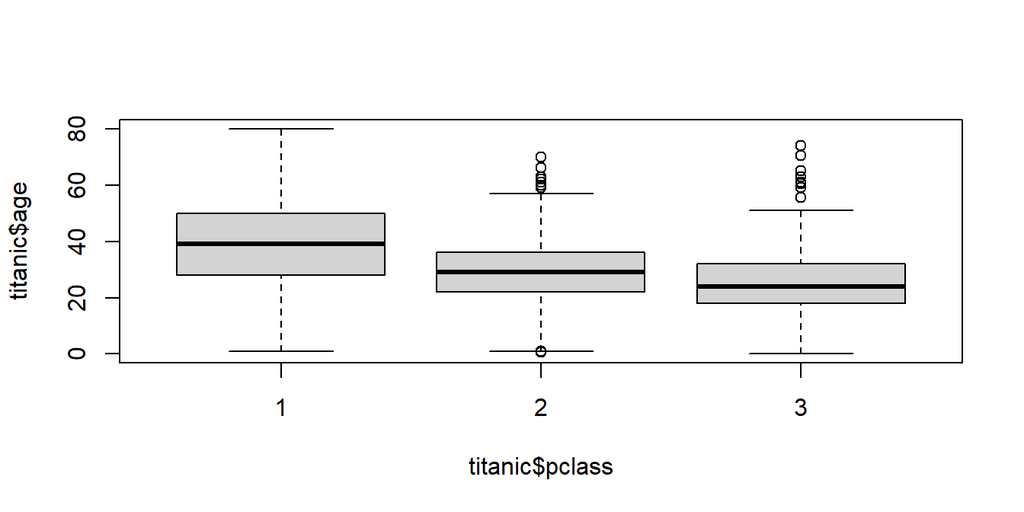

```r
boxplot(titanic$age~titanic$pclass)
```

*Reply: There is a negative correlation between passenger class and age. Passengers travelling in lower classes were younger than passengers in the first class as shown in the boxplot of age grouped by passenger class.*

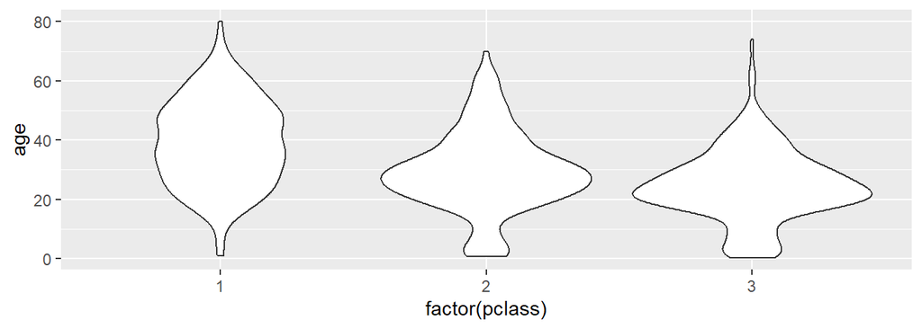

```r
library(ggplot2)
p = ggplot(titanic, aes(factor(pclass), age))
p + geom_violin(na.rm = TRUE)
```

*An alternative for the boxplot is the violin plot, a mixture of a boxplot and a kernel density function. Here it is even more obvious that there were much more young children travelling in class 2 and 3. Especially young children had a good chance for survival. In order to estimate the true effect of age we need to adjust for passenger class (either in a fixed or random effects model). Otherwise the estimate would be confounded since there where few children travelling first class.*